# Cardiovascular model in Appendix 5.3 | Real data

This notebook contains the code of the paper "Learning Physics between Digital Twins with Low-Fidelity Models and Physics-Informed Gaussian Processes". The models are fitted in rstan and the code is available in the folder "STAN/WK2_periodic".

#### Load packages

```r
# uncomment to install
# install.packages("rstan")
# install.packages("ggplot2")
# install.packages("latex2exp")
library(rstan)
library(ggplot2)
library(latex2exp)

rstan_options(auto_write = TRUE)
options(mc.cores = 3) # allocate 3 cores (for each model we run 3 chains in parallel)
```

### Load posterior samples

First, we load the posterior samples from the fitted models obtained by the models in 'WK_trial_data.Rmd'.

```r
# choose some reasonable physical parameter values
data_trial = readRDS("Data/data_trial.rds")
dat = readRDS("Data/post_wk2_trial.rds") # posterior data for all models
test_data = readRDS("Data/test_data.rds")
attach(dat)
lP_pr = lI_pr = list()
t1=Sys.time()
nc=2
nP=dat$data$nP
nI=dat$data$nI
Ns=dat$data$Ns
nP_pred=nrow(test_data[[1]]$dfP_pred); nI_pred=nrow(test_data[[1]]$dfP_pred);
```

### Model 1 (no-without $\delta(t)$ in paper, Figure 9)

This is the misspecified model that does not account for model discrepancy (no-without $\delta(t)$ in paper, Figure 9). For more details on prediction equations see Appendix C.2.

Stan code:

```r
# writeLines(readLines("STAN/WK2_periodic/WK2_per_nodelta_pred.stan"))
```

We predict for each individual $m=1,\ldots,8$

```r
#----------------------------------------------------------------
# no-without delta
#----------------------------------------------------------------
post_nnd=l_df_nnd
N_samples = nrow(post_nnd[[1]])
for (i in 1:Ns){
  data_pred = list(nP=nP, nI=nI, tP=data_trial$tP[i,], tI=data_trial$tI[i,], yP=data_trial$yP[i,], yI=data_trial$yI[i,]
                   , tP_pred = test_data[[i]]$dfP_pred$time, tI_pred=test_data[[i]]$dfQ_pred$time
                   , nP_pred=nP_pred, nI_pred=nI_pred
                   , alpha=post_nnd[[i]]$alpha, rho=post_nnd[[i]]$rho
                   , sigmaP=post_nnd[[i]]$sigmaP, sigmaI=post_nnd[[i]]$sigmaQ
                   , R=post_nnd[[i]]$R, C=post_nnd[[i]]$C, N_samples=N_samples, yDia=data_trial$yDia, p = data_trial$p[i]
  )
  pred = stan(file = "STAN/WK2_periodic/WK2_per_nodelta_pred.stan",
              data = data_pred,
              chains = 1, iter = 1, seed=123,
              algorithm = "Fixed_param")
  ex_pred=extract(pred)
  Pvec = ex_pred$y_P
  Ivec = ex_pred$y_I
  P_post=matrix(NA, ncol = 3, nrow = nP_pred)
  # calculate mean and 95% CIs
  for(n in 1:nP_pred){
    ind=(1 +(n-1)*N_samples):(n*N_samples)
    v = Pvec[ind]
    P_post[n,] = c(mean(v), quantile(v, probs = 0.025), quantile(v, probs = 0.975))
  }
  I_post=matrix(NA, ncol = 3, nrow = nI_pred)
  for(n in 1:nI_pred){
    ind=(1 +(n-1)*N_samples):(n*N_samples)
    v = Ivec[ind]
    I_post[n,] = c(mean(v), quantile(v, probs = 0.025), quantile(v, probs = 0.975))
  }

  lP_pr[[i]]=P_post
  lI_pr[[i]]=I_post
}
```

```r
# prepare the data for plotting

ID = paste0("ID = ", 1:Ns)
# R1 = paste("expression(R[1] = )", Zvec)
P_nnd = data.frame(do.call(rbind, lP_pr))
P_nnd$ID = rep(ID, each = nP_pred)
tP_pred = list()
for(i in 1:length(test_data)){
  tP_pred[[i]] = test_data[[i]]$dfP_pred$time
}
P_nnd$time = unlist(tP_pred)
colnames(P_nnd)[1:3] = c("mean", "lower", "upper")
P_nnd$sharing = "no-without delta"

I_nnd = data.frame(do.call(rbind, lI_pr))
I_nnd$ID = rep(ID, each = nI_pred)
tI_pred = list()
for(i in 1:length(test_data)){
  tI_pred[[i]] = test_data[[i]]$dfQ_pred$time
}
I_nnd$time = unlist(tI_pred)
colnames(I_nnd)[1:3] = c("mean", "lower", "upper")
I_nnd$sharing = "no-without delta"

rmse = function(actual,pred) sqrt(mean((actual - pred)^2))
P_rmse_nnd = rep(NA,8)
for(i in 1:Ns) P_rmse_nnd[i] = rmse(test_data[[i]]$dfP_pred$P, P_nnd[P_nnd$ID == paste0("ID = ", i),"mean"])
P_rmse_nnd
```

```
[1]  9.828503 10.620614 12.920194 13.104613  3.902423  7.819485  4.109590
[8] 10.885817
```

### Model 2 (no-with $\delta(t)$ in paper, Figure 9)

Now we account for model discrepancy $\delta_m(x_m)\sim GP(0,K_\delta(x_m,x_m')),$ where we use the periodic k kernel $K_{\delta}(t,t') = \alpha_{\delta}^2\exp\left(-\frac{2\sin^2(\pi(t - t')/p)}{\rho_{\delta}^2}\right).$ More details on the prediction equations are given in the Appendix C.2.

Stan code:

```r
# writeLines(readLines("STAN/WK2_periodic/WK2_per_delta_pred.stan"))
```

We predict for each individual $m=1,\ldots,8$

```r
post_nwd=l_df_nwd
N_samples = nrow(post_nwd[[1]])
# no-with delta model
for (i in 1:Ns){
  data_pred = list(nP=nP, nI=nI, tP=data_trial$tP[i,], tI=data_trial$tI[i,], yP=data_trial$yP[i,], yI=data_trial$yI[i,]
                 , tP_pred = test_data[[i]]$dfP_pred$time, tI_pred=test_data[[i]]$dfQ_pred$time
                 , nP_pred=nP_pred, nI_pred=nI_pred
                 , alpha=post_nwd[[i]]$alpha, rho=post_nwd[[i]]$rho
                 , sigmaP=post_nwd[[i]]$sigmaP, sigmaI=post_nwd[[i]]$sigmaQ
                 , rho_d=post_nwd[[i]]$rho_d, alpha_d=post_nwd[[i]]$alpha_d
                 , R=post_nwd[[i]]$R, C=post_nwd[[i]]$C, N_samples=N_samples, yDia=data_trial$yDia, p = data_trial$p[i]
                 )

  pred = stan(file = "STAN/WK2_periodic/WK2_per_delta_pred.stan",
              data = data_pred,
              chains = 1, iter = 1, seed=123,
              algorithm = "Fixed_param")
  ex_pred=extract(pred)
  Pvec = ex_pred$y_P
  Ivec = ex_pred$y_I
  P_post=matrix(NA, ncol = 3, nrow = nP_pred)
  for(n in 1:nP_pred){
    ind=(1 +(n-1)*N_samples):(n*N_samples)
    v = Pvec[ind]
    P_post[n,] = c(mean(v), quantile(v, probs = 0.025), quantile(v, probs = 0.975))
  }
  I_post=matrix(NA, ncol = 3, nrow = nI_pred)
  for(n in 1:nI_pred){
    ind=(1 +(n-1)*N_samples):(n*N_samples)
    v = Ivec[ind]
    I_post[n,] = c(mean(v), quantile(v, probs = 0.025), quantile(v, probs = 0.975))
  }

  lP_pr[[i]]=P_post
  lI_pr[[i]]=I_post
}
```

```r
# prepare data for plotting

#ID = paste0("ID = ", 1:Ns)
P_nwd = data.frame(do.call(rbind, lP_pr))
P_nwd$ID = rep(ID, each = nP_pred)
tP_pred = list()
for(i in 1:length(test_data)){
  tP_pred[[i]] = test_data[[i]]$dfP_pred$time
}
P_nwd$time = unlist(tP_pred)
colnames(P_nwd)[1:3] = c("mean", "lower", "upper")
P_nwd$sharing = "no-with delta"

I_nwd = data.frame(do.call(rbind, lI_pr))
I_nwd$ID = rep(ID, each = nI_pred)
tI_pred = list()
for(i in 1:length(test_data)){
  tI_pred[[i]] = test_data[[i]]$dfQ_pred$time
}
I_nwd$time = unlist(tI_pred)
colnames(I_nwd)[1:3] = c("mean", "lower", "upper")
I_nwd$sharing = "no-with delta"
P_rmse_nwd = rep(NA,Ns)
for(i in 1:Ns) P_rmse_nwd[i] = rmse(test_data[[i]]$dfP_pred$P, P_nwd[P_nwd$ID == paste0("ID = ", i),"mean"])
P_rmse_nwd
```

```
[1] 2.511542 2.586334 2.594740 7.343977 1.346035 1.728751 2.589026 3.116613
```

### Model 3 (yes/common $\delta(t)$ in paper, Figure 9)

We allow individuals to share information about the physical parameters $u_m, m=1,2,\ldots,8$ through a global level parameter as described in Section 3.2. The model assumes same discrepancy parameters for all individuals.

We predict using the same equations as before, but now with the posterior distributions obtained by the fit of Model 3 (yes/common $\delta(t)$).

```r
post_ycd=list()

for(i in 1:Ns){
  v=c(paste0("alpha.",i), paste0("rho.",i), "alpha_d", "rho_d", paste0("sigmaP.",i), paste0("sigmaI.",i), paste0("R.",i), paste0("C.", i))
  df_temp=df_ycd[, v]
  colnames(df_temp)=c("alpha", "rho", "alpha_d", "rho_d", "sigmaP", "sigmaI", "R", "C")
  post_ycd[[i]]=df_temp
}

# yes/common delta model
for (i in 1:Ns){
  data_pred = list(nP=nP, nI=nI, tP=data_trial$tP[i,], tI=data_trial$tI[i,], yP=data_trial$yP[i,], yI=data_trial$yI[i,]
                   , tP_pred = test_data[[i]]$dfP_pred$time, tI_pred=test_data[[i]]$dfQ_pred$time
                   , nP_pred=nP_pred, nI_pred=nI_pred
                   , alpha=post_ycd[[i]]$alpha, rho=post_ycd[[i]]$rho
                   , sigmaP=post_ycd[[i]]$sigmaP, sigmaI=post_ycd[[i]]$sigmaI
                   , rho_d=post_ycd[[i]]$rho_d, alpha_d=post_ycd[[i]]$alpha_d
                   , R=post_ycd[[i]]$R, C=post_ycd[[i]]$C, N_samples=N_samples, yDia=data_trial$yDia, p = data_trial$p[i]
  )

  pred = stan(file ="STAN/WK2_periodic/WK2_per_delta_pred.stan",
              data = data_pred,
              chains = 1, iter = 1, seed=123,
              algorithm = "Fixed_param")
  ex_pred=extract(pred)
  Pvec = ex_pred$y_P
  Ivec = ex_pred$y_I
  P_post=matrix(NA, ncol = 3, nrow = nP_pred)
  for(n in 1:nP_pred){
    ind=(1 +(n-1)*N_samples):(n*N_samples)
    v = Pvec[ind]
    P_post[n,] = c(mean(v), quantile(v, probs = 0.025), quantile(v, probs = 0.975))
  }
  I_post=matrix(NA, ncol = 3, nrow = nI_pred)
  for(n in 1:nI_pred){
    ind=(1 +(n-1)*N_samples):(n*N_samples)
    v = Ivec[ind]
    I_post[n,] = c(mean(v), quantile(v, probs = 0.025), quantile(v, probs = 0.975))
  }

  lP_pr[[i]]=P_post
  lI_pr[[i]]=I_post
}
```

```r
# prepare data for plotting

#ID = paste0("ID = ", 1:Ns)
P_ycd = data.frame(do.call(rbind, lP_pr))
P_ycd$ID = rep(ID, each = nP_pred)
tP_pred = list()
for(i in 1:length(test_data)){
  tP_pred[[i]] = test_data[[i]]$dfP_pred$time
}
P_ycd$time = unlist(tP_pred)
colnames(P_ycd)[1:3] = c("mean", "lower", "upper")
P_ycd$sharing = "yes/common delta"

I_ycd = data.frame(do.call(rbind, lI_pr))
I_ycd$ID = rep(ID, each = nI_pred)
tI_pred = list()
for(i in 1:length(test_data)){
  tI_pred[[i]] = test_data[[i]]$dfQ_pred$time
}
I_ycd$time = unlist(tI_pred)
colnames(I_ycd)[1:3] = c("mean", "lower", "upper")
I_ycd$sharing = "yes/common delta"

P_rmse_ycd = rep(NA,8)
for(i in 1:Ns) P_rmse_ycd[i] = rmse(test_data[[i]]$dfP_pred$P, P_ycd[P_ycd$ID == paste0("ID = ", i),"mean"])
P_rmse_ycd
```

```
[1] 2.562913 2.762996 2.797537 4.558228 1.283168 1.735943 2.662421 3.155369
```

### Model 4 (yes/shared $\delta(t)$ in paper, Figure 9)

We predict using the same equations as before, but now with the posterior distributions obtained by the fit of Model 4 (yes/shared $\delta (t)$).

```r
#-------------------------------------------------------
# yes/ shared delta
#----------------------------------------------------------------
post_ysd = list()

for(i in 1:Ns){
  v=c(paste0("alpha.",i), paste0("rho.",i), paste0("alpha_d.",i), paste0("rho_d.",i), paste0("sigmaP.",i), paste0("sigmaI.",i), paste0("R.",i), paste0("C.", i))
  df_temp=df_ysd[, v]
  colnames(df_temp)=c("alpha", "rho", "alpha_d", "rho_d", "sigmaP", "sigmaI", "R", "C")
  post_ysd[[i]]=df_temp
}

# yes/common delta model
for (i in 1:Ns){
  data_pred = list(nP=nP, nI=nI, tP=data_trial$tP[i,], tI=data_trial$tI[i,], yP=data_trial$yP[i,], yI=data_trial$yI[i,]
                   , tP_pred = test_data[[i]]$dfP_pred$time, tI_pred=test_data[[i]]$dfQ_pred$time
                   , nP_pred=nP_pred, nI_pred=nI_pred
                   , alpha=post_ysd[[i]]$alpha, rho=post_ysd[[i]]$rho
                   , sigmaP=post_ysd[[i]]$sigmaP, sigmaI=post_ysd[[i]]$sigmaI
                   , rho_d=post_ysd[[i]]$rho_d, alpha_d=post_ysd[[i]]$alpha_d
                   , R=post_ysd[[i]]$R, C=post_ysd[[i]]$C, N_samples=N_samples, yDia=data_trial$yDia, p = data_trial$p[i]
  )

  pred = stan(file = "STAN/WK2_periodic/WK2_per_delta_pred.stan",
              data = data_pred,
              chains = 1, iter = 1, seed=123,
              algorithm = "Fixed_param")
  ex_pred=extract(pred)
  Pvec = ex_pred$y_P
  Ivec = ex_pred$y_I
  P_post=matrix(NA, ncol = 3, nrow = nP_pred)
  for(n in 1:nP_pred){
    ind=(1 +(n-1)*N_samples):(n*N_samples)
    v = Pvec[ind]
    P_post[n,] = c(mean(v), quantile(v, probs = 0.025), quantile(v, probs = 0.975))
  }
  I_post=matrix(NA, ncol = 3, nrow = nI_pred)
  for(n in 1:nI_pred){
    ind=(1 +(n-1)*N_samples):(n*N_samples)
    v = Ivec[ind]
    I_post[n,] = c(mean(v), quantile(v, probs = 0.025), quantile(v, probs = 0.975))
  }

  lP_pr[[i]]=P_post
  lI_pr[[i]]=I_post
}
```

```r
# prepare data for plotting

#ID = paste0("ID = ", 1:Ns)
P_ysd = data.frame(do.call(rbind, lP_pr))
P_ysd$ID = rep(ID, each = nP_pred)
tP_pred = list()
for(i in 1:length(test_data)){
  tP_pred[[i]] = test_data[[i]]$dfP_pred$time
}
P_ysd$time = unlist(tP_pred)
colnames(P_ysd)[1:3] = c("mean", "lower", "upper")
P_ysd$sharing = "yes/shared delta"

I_ysd = data.frame(do.call(rbind, lI_pr))
I_ysd$ID = rep(ID, each = nI_pred)
tI_pred = list()
for(i in 1:length(test_data)){
  tI_pred[[i]] = test_data[[i]]$dfQ_pred$time
}
I_ysd$time = unlist(tI_pred)
colnames(I_ysd)[1:3] = c("mean", "lower", "upper")
I_ysd$sharing = "yes/shared delta"
# P_ysd
rmse = function(actual,pred) sqrt(mean((actual - pred)^2))

P_rmse_ysd = rep(NA,8)
for(i in 1:Ns) P_rmse_ysd[i] = rmse(test_data[[i]]$dfP_pred$P, P_ysd[P_ysd$ID == paste0("ID = ", i),"mean"])
rmses=colMeans(cbind(P_rmse_nnd,P_rmse_nwd,P_rmse_ycd,P_rmse_ysd))
round(rmses,2)
```

```
P_rmse_nnd P_rmse_nwd P_rmse_ycd P_rmse_ysd
      9.15       2.98       2.69       2.61
```

```r
# df_rmses=data.frame(matrix(rmses,nrow = 1))
# colnames(df_rmses) = c("nnd", "nwd", "ycd", "ysd")
# rownames(df_rmses) = "WK2; real data"
# df_rmses
# saveRDS(df_rmses, "Data/rmse_WK2_real.rds")
```

#### Plot pressure predictions

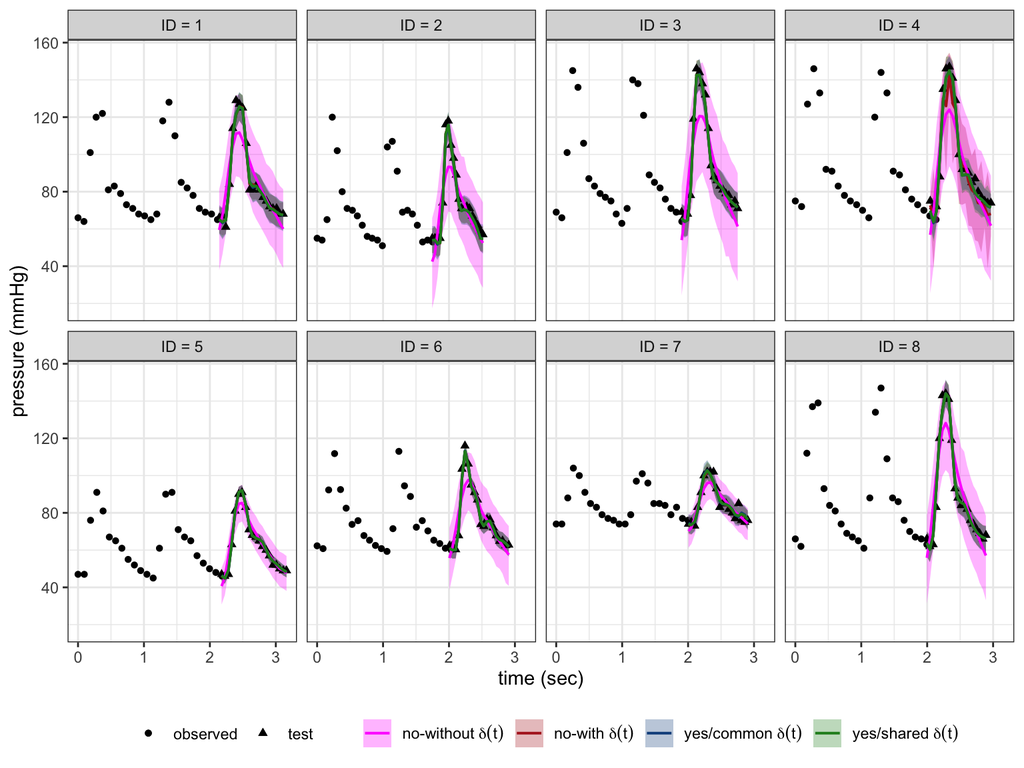

```r
P_pred = data.frame(rbind(P_nwd, P_ysd, P_ycd, P_nnd))
colnames(P_pred)[5] = "t"
npred = nP_pred
P_true = test_data[[1]]$dfP_pred
for(i in 2:Ns) P_true = rbind(P_true, test_data[[i]]$dfP_pred)
P_true$ID = rep(ID, each = npred)
P_obs = data.frame(P=as.vector(t(data_trial$yP)),t=as.vector(t(data_trial$tP)),ID = rep(ID, each = nP))

lbl=c(latex2exp('no-without $\\delta(t)$'),
                 latex2exp('no-with $\\delta(t)$'),
                 latex2exp('yes/common $\\delta(t)$'),
                 latex2exp('yes/shared $\\delta(t)$'))

pl_WK_pred_P=ggplot()+
  geom_point(data=P_obs, aes(x=t, y=P, shape="observed"))+
  geom_ribbon(data=P_pred, aes(x=t,ymin=lower,ymax=upper, fill=sharing),alpha=0.3)+
  geom_point(data=P_true, aes(x=time, y=P, shape="test"))+
  geom_line(data=P_pred, aes(x=t, y=mean, color= sharing), size=0.7)+
  facet_wrap(~ID, nrow = 2)+
  theme_bw()+
  xlab("time (sec)")+ylab("pressure (mmHg)")+
  theme(legend.position = "bottom", legend.title = element_blank())+
  scale_color_manual(
    breaks=c('no-without delta','no-with delta', "yes/common delta", "yes/shared delta", "true"),
    values=c("magenta","firebrick","dodgerblue4", "forestgreen", "black"),
    label=lbl
  )+
  scale_linetype_manual(breaks=c('no-without delta','no-with delta', "yes/common delta", "yes/shared delta", "true"),
                        values=c(1,1,1, 1, 2)
  )+
  scale_fill_manual(
    breaks=c('no-without delta','no-with delta', "yes/common delta", "yes/shared delta"),
    values=c("magenta","firebrick","dodgerblue4", "forestgreen"),
    label=lbl
  )

pl_WK_pred_P
```

```r
# ggsave("Figs/WK_real_pressure_pred.pdf", plot = pl_WK_pred_P, width = 20, height = 15, units = "cm")
```

#### Plot flow predictions (Figure 6 in Appendix)

```r
I_pred = data.frame(rbind(I_nwd, I_ysd, I_ycd, I_nnd))
colnames(I_pred)[5] = "t"
I_true = test_data[[1]]$dfQ_pred
for(i in 2:Ns) I_true = rbind(I_true, test_data[[i]]$dfQ_pred)
I_true$ID = rep(ID, each = npred)
I_obs = data.frame(I=as.vector(t(data_trial$yI)),t=as.vector(t(data_trial$tI)),ID = rep(ID, each = nI))



pl_WK_pred_I=ggplot()+
  geom_point(data=I_obs, aes(x=t, y=I, shape="observed"))+
  geom_ribbon(data = I_pred, aes(x=t,ymin=lower,ymax=upper, fill=sharing),alpha=0.3)+
  geom_point(data=I_true, aes(x=time, y=Q, shape="test"))+
  geom_line(data=I_pred, aes(x=t, y=mean, color= sharing), size=0.7)+
  facet_wrap(~ID, nrow = 2)+
  theme_bw()+
  xlab("time (sec)")+ylab("flow (ml/min)")+
  theme(legend.position = "bottom", legend.title = element_blank())+
  scale_color_manual(
    breaks=c('no-without delta','no-with delta', "yes/common delta", "yes/shared delta", "true"),
    values=c("magenta","firebrick","dodgerblue4", "forestgreen", "black")
  )+
  scale_linetype_manual(breaks=c('no-without delta','no-with delta', "yes/common delta", "yes/shared delta", "true"),
                        values=c(1,1,1, 1, 2)
  )+
  scale_fill_manual(
    breaks=c('no-without delta','no-with delta', "yes/common delta", "yes/shared delta"),
    values=c("magenta","firebrick","dodgerblue4", "forestgreen")
  )

# pl_WK_pred_I
# ggsave("Figs/WK_trial_pred_I.pdf", plot = pl_WK_pred_I, width = 20, height = 15, units = "cm")
```

```r
R_nnd = R_nwd = R_ycd = R_ysd = C_nnd = C_nwd = C_ycd = C_ysd = c()

for(i in 1:Ns){
  R_temp = post_nnd[[i]]$R
  R_nnd = c(R_nnd, R_temp)
  R_temp = post_nwd[[i]]$R
  R_nwd = c(R_nwd, R_temp)
  R_temp = post_ycd[[i]]$R
  R_ycd = c(R_ycd, R_temp)
  R_temp = post_ysd[[i]]$R
  R_ysd = c(R_ysd, R_temp)
  C_temp = post_nnd[[i]]$C
  C_nnd = c(C_nnd, C_temp)
  C_temp = post_nwd[[i]]$C
  C_nwd = c(C_nwd, C_temp)
  C_temp = post_ysd[[i]]$C
  C_ycd = c(C_ycd, C_temp)
  C_temp = post_ycd[[i]]$C
  C_ysd = c(C_ysd, C_temp)
}
id_post = rep(as.factor(1:Ns), each = N_samples)
shr = c('no-without','no-with', "yes/common", "yes/shared")
Rpost=data.frame(R = c(R_nnd, R_nwd, R_ycd, R_ysd), ID = rep(id_post,4), sharing = rep(rep(shr, each = Ns*N_samples),4))
Cpost=data.frame(C = c(C_nnd, C_nwd, C_ycd, C_ysd), ID = rep(id_post,4), sharing = rep(rep(shr, each = Ns*N_samples),4))

appender2 = function(string) {
  TeX(paste(string, "$\\delta(t)$"))
}
```

#### Plot posteriors of C for all individuals (Figure 3 in Appendix)

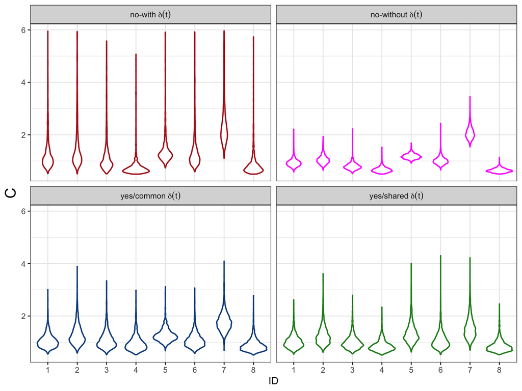

```r
# C post
(pl_C=ggplot() +
  geom_violin(data = Cpost, aes(x = ID, y=C, color = sharing),size=0.7)+
  theme_bw()+
  theme(axis.title.y = element_text(size = rel(1.5)), legend.position = "none")+
  facet_wrap(sharing~., labeller = as_labeller(appender2, default = label_parsed))+
  xlab("ID")+
  scale_color_manual(
    breaks=c('no-without', 'no-with', "yes/common", "yes/shared"),
    values=c("magenta","firebrick","dodgerblue4", "forestgreen")))
```

```r
# ggsave("Figs/post_WK_real_C.pdf", plot = pl_C, width = 18, height = 12, units = "cm")
```